# Relatório 03

Felipe Henrique

17/04/2025

# 1 Objetivo

Através da análise de um grupo de resultados, construir a ideia de poder e como as variavéis estão atreladas aos testes que podemos fazer

# 2 Apresentação do relatório

Este relatório foi dividido em quatro “experimentos” com distribuições normais diferentes em cada sessão, dentro de cada uma delas possui ainda 3 alphas diferentes, portanto ao final do relatório é possível a visualização de 12 gráficos e a explicação deles

# 3 Conceitos Iniciais

-α (alpha) é o nível de significância do teste, ele representa a probabilidade de cometer um erro tipo I, ou seja é a chance de rejeitar a hipótese nula H₀ mesmo quando ela é verdadeira.

-Poder é a probabilidade de rejeitar a hipótese nula (H₀) quando ela é falas, é a capacidade do seu teste de encontrar essa diferença quando ela realmente existe.

## 3.1 Testes com distribuição normal = 90

**grafico com alpha de 5%**

```
## Proporção de rejeições de H0 (nível empírico): 4.65 %
```

[figure not shown]

**grafico com alpha de 1%**

```
## Proporção de rejeições de H0 (nível empírico): 1.03 %
```

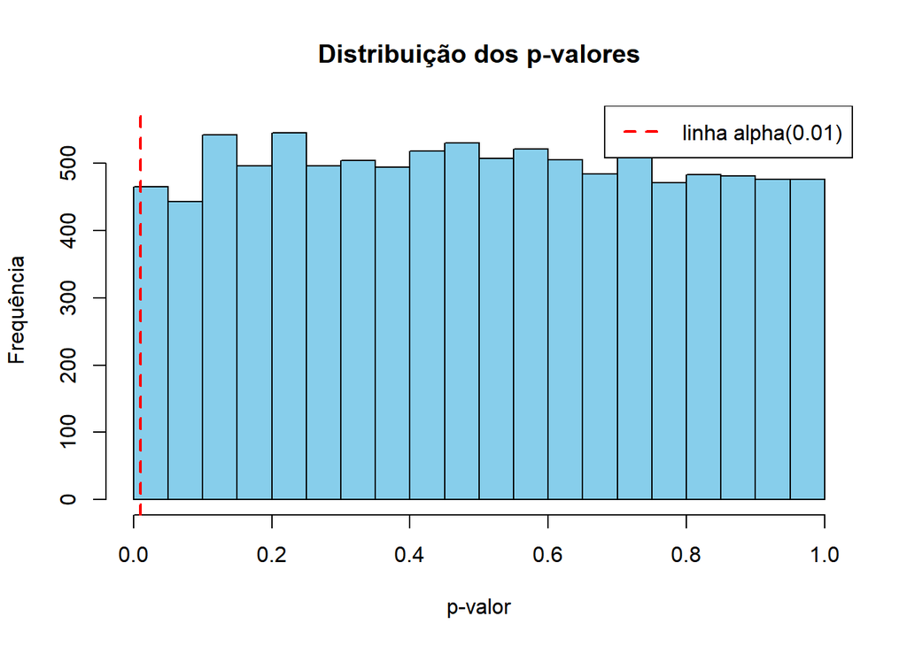

**grafico com alpha de 10%**

```
## Proporção de rejeições de H0 (nível empírico): 9.08 %
```

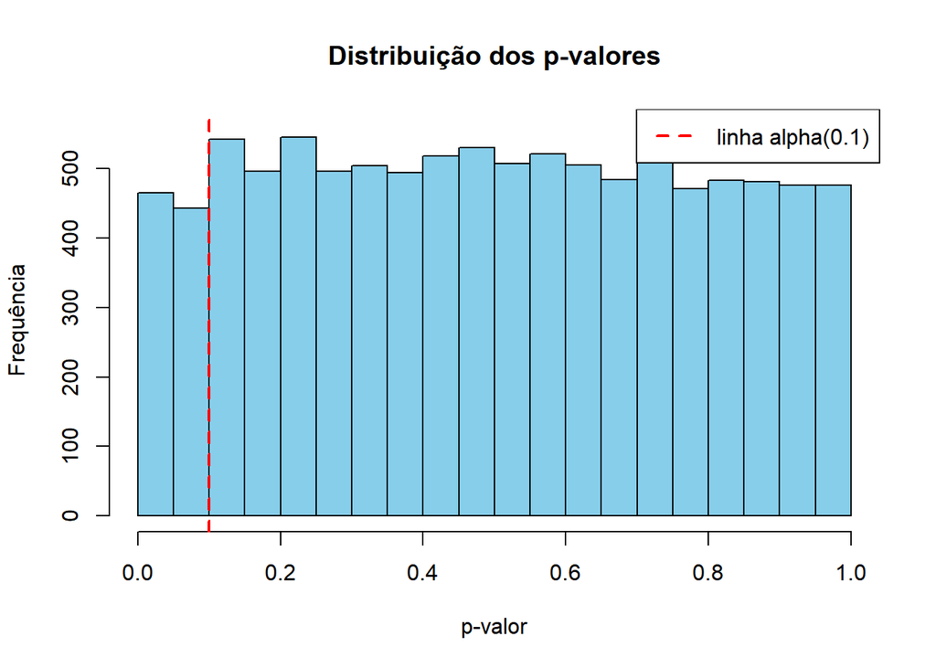

## 3.2 Testes com 1 erro padrão

**alpha 5%**

```
## Poder estimado do teste (μ₁ = 91): 0.2614
```

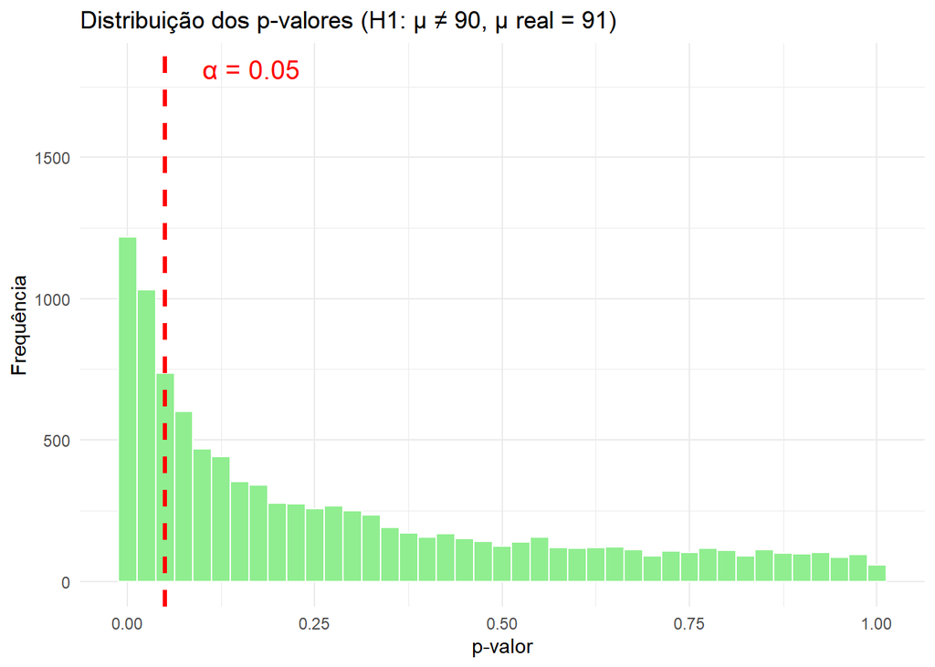

**alpha 1%**

```
## Poder estimado do teste (μ₁ = 91): 0.1054
```

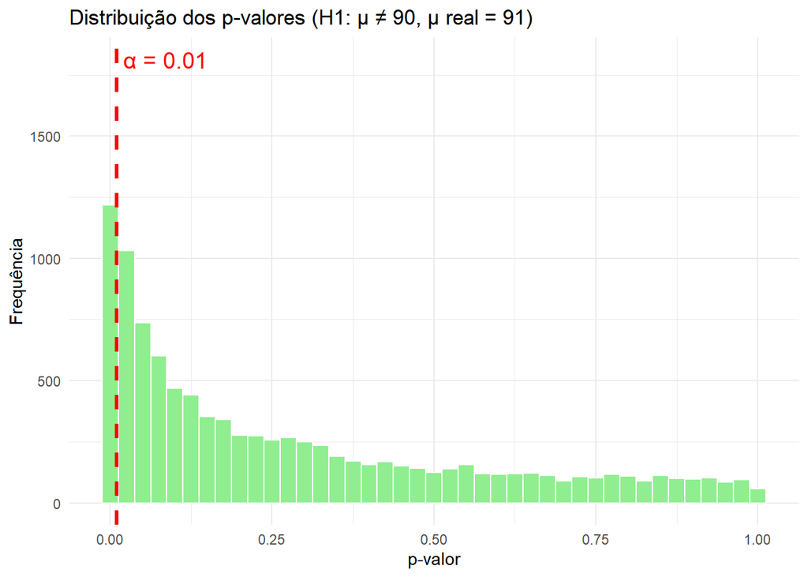

**alpha com 10%**

```
## Poder estimado do teste (μ₁ = 91): 0.3842
```

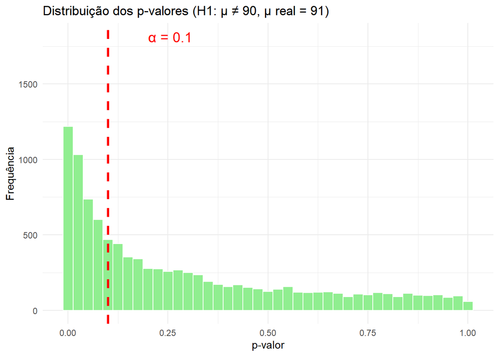

## 3.3 Testes com 2 erros padrão

**alpha 5%**

```
## Poder estimado do teste (μ₁ = 92): 0.7567
```

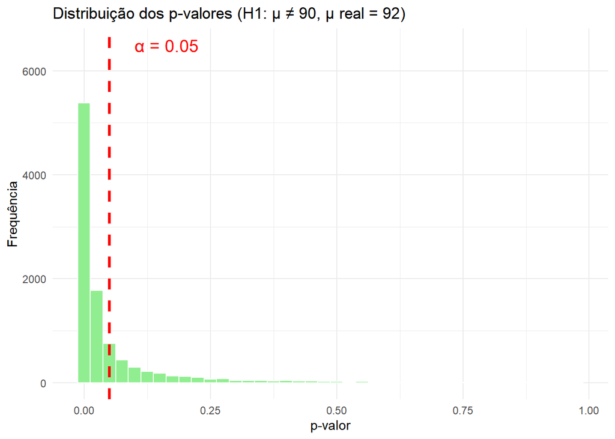

**alpha 1%**

```
## Poder estimado do teste (μ₁ = 92): 0.5026
```

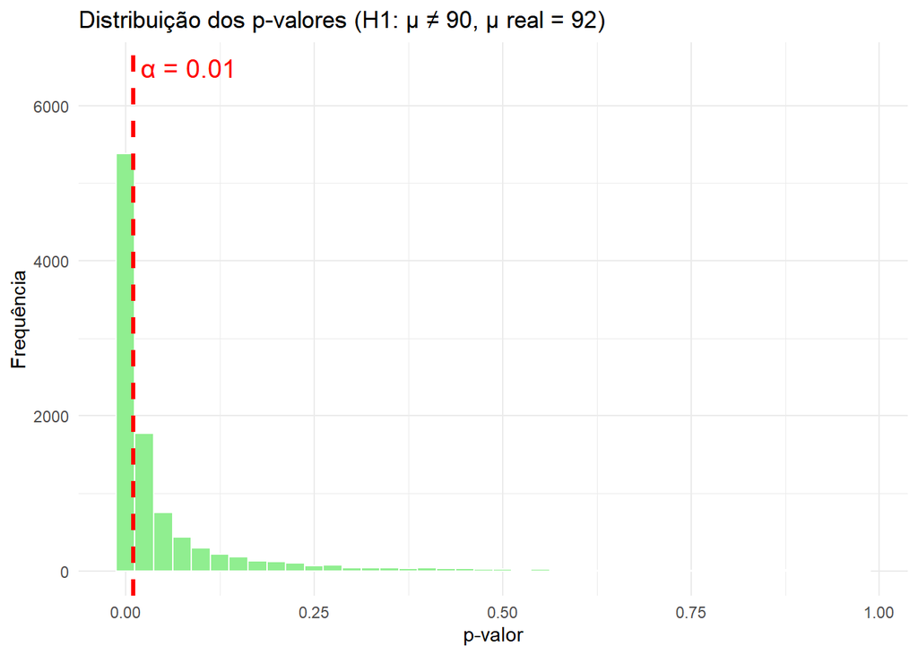

**alpha com 10%**

```
## Poder estimado do teste (μ₁ = 92): 0.8494
```

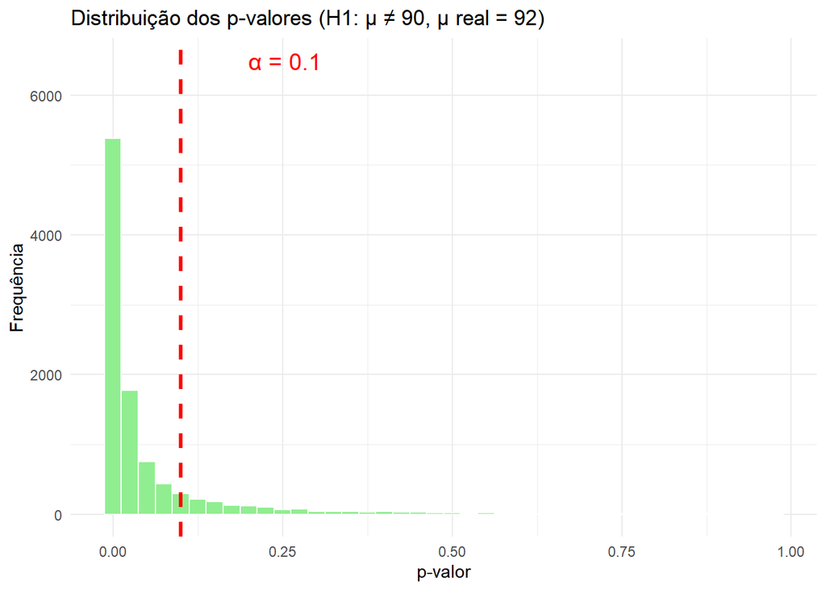

## 3.4 Testes com 3 erros padrão

**alpha 5%**

```
## Poder estimado do teste (μ₁ = 93): 0.9765
```

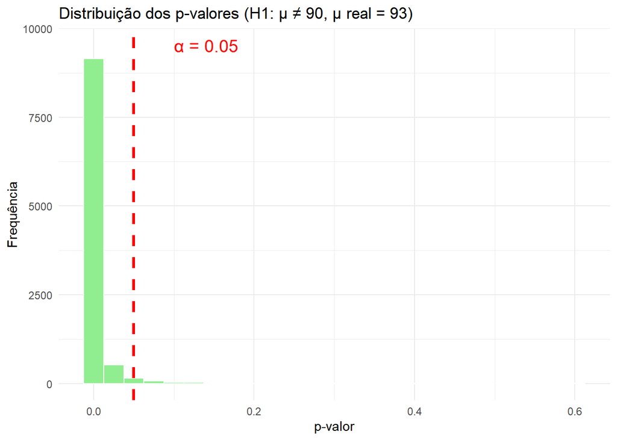

**alpha 1%**

```
## Poder estimado do teste (μ₁ = 93): 0.9018
```

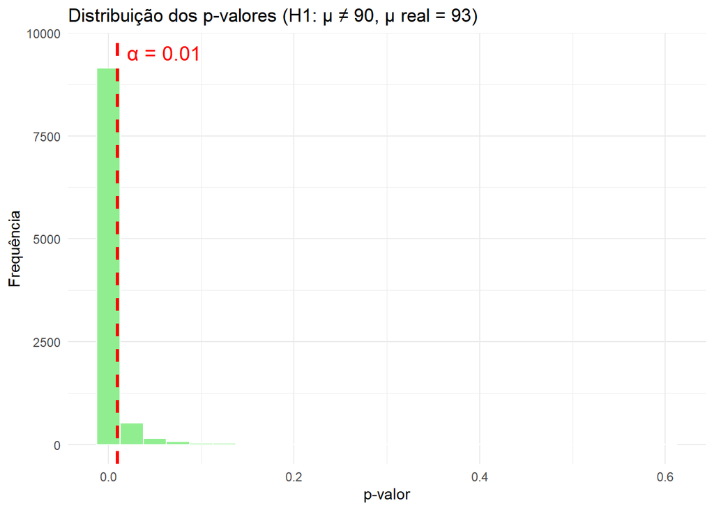

**alpha com 10%**

```
## Poder estimado do teste (μ₁ = 93): 0.9914
```

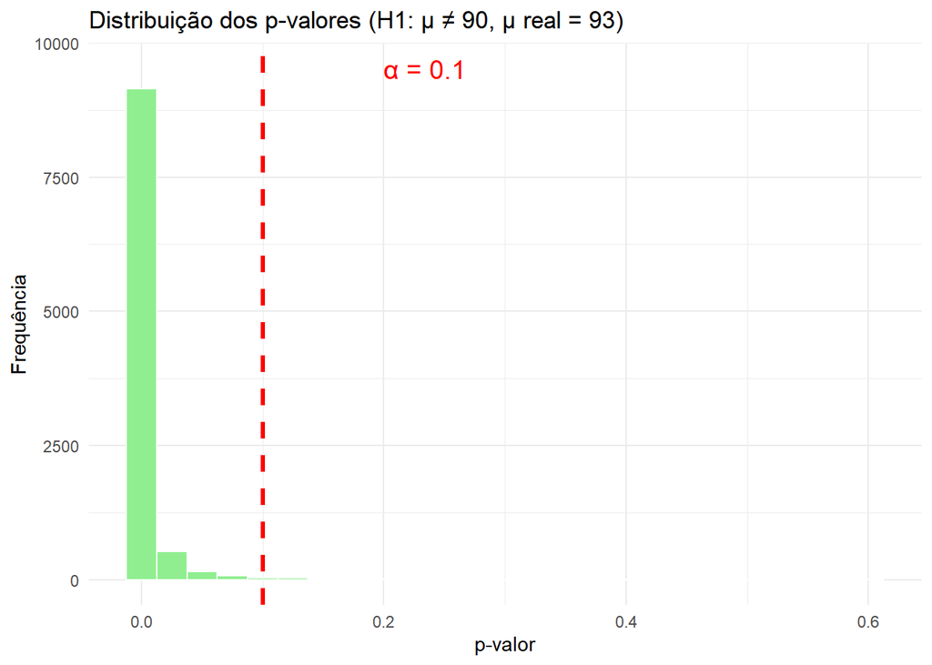

# 4 Conclusão

Conclui-se que quanto maior seu alpha maior é o seu poder, quando se presupõe que H0 é verdadeira, as populações tendem a ser mais homogêneas e se comporta de forma mais previsível